# Pacote HidrowebR: Roteiro de uso

Aquisição automatizada,pré e pós processamento dos dados disponibilizados pela HidroWEB - ANA

Galera

2022-04-30

## 1 Introdução

Este roteiro tem como objetivo apresentar as funcionalidades do pacote em desenvolvimento hidrowebr. Será apresentado o uso prático das funções desenvolvidas para pré e pós-processamento dos dados hidrológicos fornecidos pela ANA. A funções compreendem desde a aquisição automátizada dos dados até o preenchimento de falhas.

## 2 Área Estudo de Caso

Para exemplificar o uso das funções do pacote, foi escolhida a bacia hidrográfica do rio **Piancó-Piranhas-Açu**, porção localizada no estado da Paraíba. A bacia pode ser vizualizada abaixo.

[interactive chart not shown]

## 3 Download dos fluviométricos

Neste exemplo, iremos realizar o download dos dados das estações fluviométrica disponíveis para a bacia. Primeiro iremos encontrar quais estados estão presentes nos limites da bacia.

```
## Using year 2017
```

```
## although coordinates are longitude/latitude, st_intersection assumes that they are planar
```

```
## [1] "CEARÁ"               "RIO GRANDE DO NORTE" "PARAÍBA"
## [4] "PERNAMBUCO"
```

**Note!** Devido diferenças entre o limites dos vetores da bacia e dos estados, a função pode retornar estados não presentes na bacia trazendo estações fora da área de estudo.

### 3.1 Obtendo o iventário de estações para a área de estudo

Agora iremos utilizar a função `inventory` para realizar o download do iventário de estações para área de estudo. Abaixo uma amostra das estações encontradas.

```
## [1] "CEARÁ"
## [1] "RIO GRANDE DO NORTE"
## [1] "PARAÍBA"
## [1] "PERNAMBUCO"
```

```
## although coordinates are longitude/latitude, st_intersection assumes that they are planar
```

```
## Simple feature collection with 6 features and 4 fields
## Geometry type: POINT
## Dimension:     XY
## Bounding box:  xmin: -38.5956 ymin: -7.6314 xmax: -37.3894 ymax: -6.44
## Geodetic CRS:  WGS 84
##                   state station_code area_km2  stationType
## 476 RIO GRANDE DO NORTE     37236000     1440 fluviometric
## 479 RIO GRANDE DO NORTE     37413000    18100 fluviometric
## 487 RIO GRANDE DO NORTE     37470002     <NA> fluviometric
## 695             PARAÍBA     37130000     <NA> fluviometric
## 696             PARAÍBA     37130010     <NA> fluviometric
## 697             PARAÍBA     37200000      400 fluviometric
##                      geometry
## 476     POINT (-38.2 -6.8167)
## 479    POINT (-37.3894 -6.44)
## 487    POINT (-37.3894 -6.44)
## 695  POINT (-38.5956 -7.6314)
## 696    POINT (-38.5947 -7.63)
## 697 POINT (-38.4833 -7.11667)
```

Agora é possível vizualizar as estações fluviométricas presentes na bacia.

[interactive chart not shown]

**Note!** No download do iventário estarão presentes todas as estações disponíveis no sitema HidroWEB, isso incluem estações desativadas e sem dados.

### 3.2 Aquisição automatizada dos dados

O próximo passo é utilizar a função `stationsData` para realizar o download de todas as séries de vazão disponíveis para cada estação obtida no iventário. Neste exemplo utilizamos o argumento padrão da função `deleteNAstations = TRUE` para realizar a remoção automática de estações sem dados.

Abaixo os códigos das estações com dados presentes e uma amostra dos dados para a estação de código 37413000.

[output not shown]

[output cut: 144 more lines]

```
##  [1] "37413000" "37220000" "37230000" "37260000" "37260001" "37290000"
##  [7] "37297000" "37320000" "37340000" "37350000" "37360000" "37369100"
## [13] "37380000" "37410000" "37412000" "37430000" "37490000"
```

```
##   estacaocodigo nivelconsistencia       data mediadiaria metodoobtencaovazoes
## 1      37413000                 1 2021-08-01           1                    1
## 2      37413000                 1 2021-08-01           1                    1
## 3      37413000                 1 2021-07-01           1                    1
## 4      37413000                 1 2021-07-01           1                    1
## 5      37413000                 1 2021-06-01           1                    1
## 6      37413000                 1 2021-06-01           1                    1
##    maxima minima  media diamaxima diaminima maximastatus minimastatus
## 1  1.7526 1.0416 1.1855         1        17            1            1
## 2  0.9357  0.503 0.5888         1        17            1            1
## 3 11.9436 0.7769 2.6804        24         1            1            1
## 4  8.6645  0.353 1.6531        24         1            1            1
## 5  2.3402 0.8173 1.3092         1        30            1            1
## 6   1.316 0.3754  0.667         1        30            1            1
##   mediastatus mediaanual mediaanualstatus vazao01 vazao02 vazao03 vazao04
```

[output cut: 76 more lines]

### 3.3 Limpar e organizar os dados

O sistema HidroWEB trás diversos dados para cada estação fluviométrica além da vazão e da data de medição. Os dados das estações também estão estruturados no formato conhecido como wide. Nessa estrutura cada linha representa uma estação e todos os outros dados estão em colunas como foi apresentado no tópico anterior.

Iremos utilizar a função `organize` para remover algumas informações as quais julgamos desnecessárias e mudar a estrutura dos dados para long. No formato long os dados de vazão diária estarão em linhas, este formato facilita a utilização em diversas aplicações sobre estudos hidrológicos. É possível verificar uma amostra dos dados organizados abaixo bem como o mapa das estações com dados presentes.

[output not shown]

```
## # A tibble: 5,145 × 4
## # Groups:   date [5,145]
##    station_code consistency_level date       streamflow_m3_s
##    <chr>        <chr>             <date>               <dbl>
##  1 37413000     2                 2007-08-01          NA
##  2 37413000     2                 2007-08-02           0.225
##  3 37413000     2                 2007-08-03           0.225
##  4 37413000     2                 2007-08-04           0.196
##  5 37413000     2                 2007-08-05           1.16
##  6 37413000     2                 2007-08-06           1.68
##  7 37413000     2                 2007-08-07           1.08
##  8 37413000     2                 2007-08-08           0.991
##  9 37413000     2                 2007-08-09           0.835
## 10 37413000     2                 2007-08-10           0.697
## # … with 5,135 more rows
```

[interactive chart not shown]

## 4 Vizualização dos dados

Após a utilização da função `organize`, é possível utilizar a função `mMonthlyPlot` para visualizar os dados das estações. A função `mMonthlyPlot` converte os dados diários de vazão para as médias mensais para apresentação gráfica. Além disso, é possível nos argumentos aplicar um filtro nas estações baseado na porcentagem de falhas, tamanho da série e consistência dos dados.

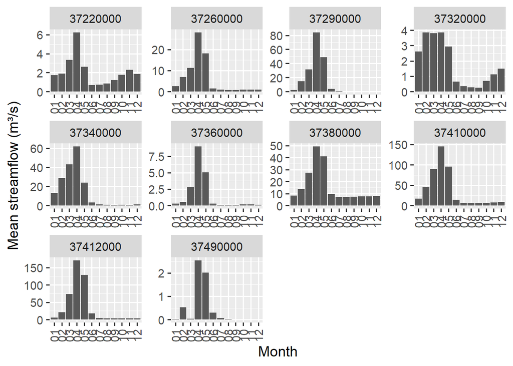

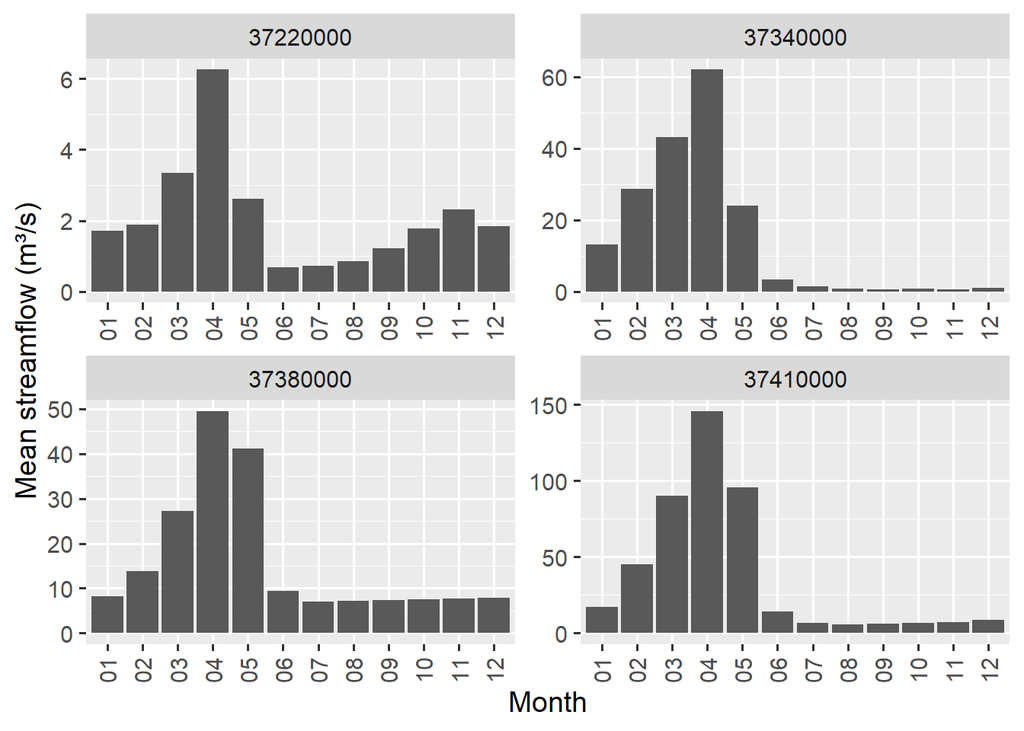

## 5 Selecionar e filtrar dados

Para selecionar e filtrar as estações foi desenvolvida a função `selectStations`. Nesta função o usuário pode aplicar um filtro nas estações nos modos mensais e anuais. Também é possível definir outros parâmetros para a filtragem das estações como porcentagem máxima de falhas, número mínimo de anos.

Na figura abaixo definimos as estações com o máximo de um por cento de falhas no modo anual.

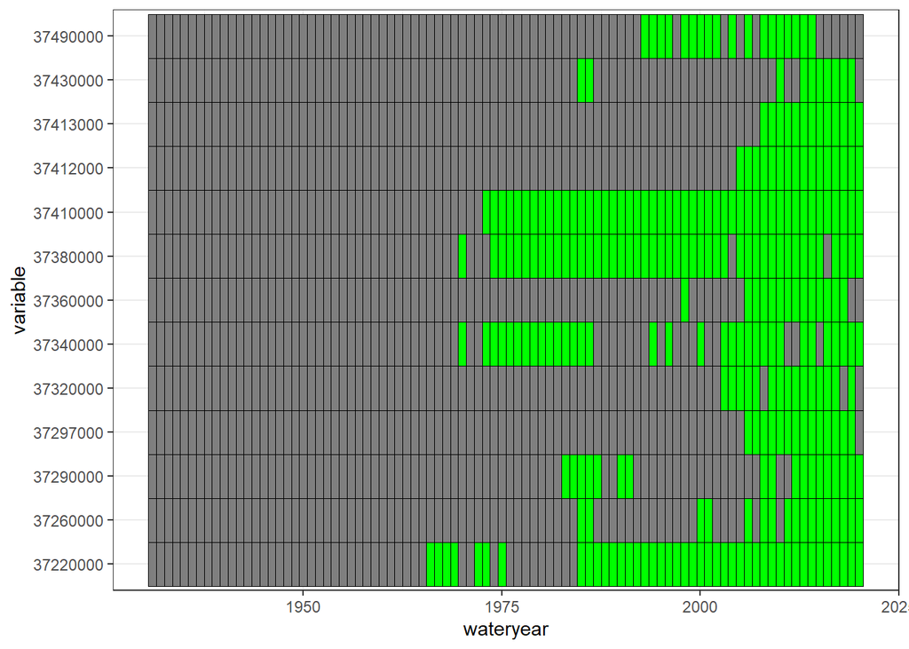

**Note!** É importante verificar a data inicial e final das séries contidas nas estações bem como a escolha do ano hidrológico.

## 6 Preenchimento de falhas

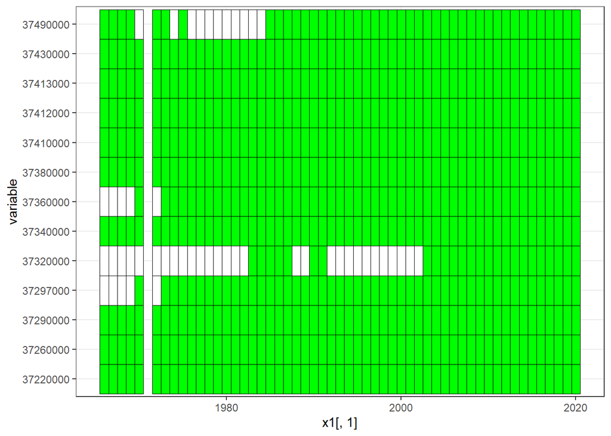

```r
dfMean = flowStatistics(list = dadosFluSelect, statistics = "Qmean")

dfFillmean = fillGaps(lista = dfMean, minimumCor = 0.85, minimunObsPairs = 5)
```